# Quiz One

## Instructions:

Solve all problems in python to the best of your ability. You are welcome to use Excel in order to check your answers, but you must submit a python notebook exported as an html file to receive full credit. Furthermore, feel free to collaborate with your fellow classmates. You need to turn in your own copy of the notebook. All figures must contain your name in the title in order to receive full credit.

### Due Date: Wednesday, February 21 2024 at 11.59pm

# Urbaczewski's Putters

We are revisiting a transshipment problem similar to one that we solved in the second class of Week 2. In this problem, Urbaczewski's Putters is the manufacturer of the finest milled golf putters available. There are three plants that manufacture the putters, two distribution centers, and five warehouses. We need to ship the putterss to the warehouses at a minimum cost satisfying the constraints outlined in the spreadsheet. Namely, each plant can only produce so much product, the number of putters passing through the distribution centers has to remain constant (in has to equal out), and each warehouse has a minimum amount that they need in order to satisfy demand. The data are given in the Excel file `quiz-1.xlsx`.

## Solve the following problems.

1. What is the minimum cost to ship these putters from our plants to the warehouses while satisfying all of our constraints?
2. What are the final values of the decision variables?
3. Is there any slack in the system? If so, what is the amount/route that shows slack?
4. Suppose management tells us that the per unit shipping cost from Plant P3 to Distribution Center D1 is going to change to \$.62. How do your answers to 1. and 2. change?
5. Show the values of the decision variables as barcharts using `seaborn`. Create a separate plot for Plants to Distribution Centers (colored by DCs) and another for DCs to Warehouses (colored by WHs).
6. Create a sequence of shipping costs (P3 to D1) from 0.55 to 0.75 in one cent increments (21 unique values).

   a. Make a plot showing how the overall shipping costs change as a function of this sequence.

   b. Make two plots showing: (1) the number of putters shipped between Plant P3 and the two distribution centers and (2) the number of putters shipped between each distribution center and the five warehouses. The lines be shown using different colors.
7. Finally, let's investigate how changing the demand on the third warehouse changes the final value of the objective function. Create a sequence of demands from 5700 to 8200 by 100 units. Plots those demands on the x axis and the final minimum cost on the y.

### Import Modules

```python
!pip install pyomo
!apt-get install -y -qq glpk-utils
import pandas as pd
import pyomo.environ as pe
import matplotlib.pyplot as plt
import seaborn as sns
```

### Read and convert data

```python
import os
from google.colab import drive
drive.mount('/content/drive')
os.chdir('/content/drive/My Drive/Colab Notebooks')
xlsx_file = pd.ExcelFile('quiz-1.xlsx')
xlsx_file.sheet_names
```

```
["Urbaczewski's Putters", 'Coef', 'RHS']
```

#### Problem 1

Cost DataFrame for Plants to Distribution Centers

```python
cost = pd.read_excel(xlsx_file, sheet_name = 'Coef', index_col = 0, usecols = [0,1,2])
cost
```

| (From) Plant | D1 | D2 |
| --- | --- | --- |
| P1 | 0.50 | 0.60 |
| P2 | 0.65 | 0.65 |
| P3 | 0.63 | 0.78 |

Cost DataFrame for Distribution Centers to Warehouses

```python
cost2 = pd.read_excel(xlsx_file, sheet_name = 'Coef', index_col = 0, usecols = [4,5,6,7,8,9])
cost2
```

| (From) DC | W1 | W2 | W3 | W4 | W5 |
| --- | --- | --- | --- | --- | --- |
| D1 | 0.5 | 0.4 | 0.3 | 0.5 | 0.72 |
| D2 | 0.7 | 0.6 | 0.2 | 0.5 | 0.55 |
| NaN | NaN | NaN | NaN | NaN | NaN |

Capacity and Demand DataFrames

```python
demand = pd.read_excel(xlsx_file, sheet_name = 'RHS', index_col = 0, usecols = [2,3])
capacity = pd.read_excel(xlsx_file, sheet_name = 'RHS', index_col = 0, usecols = [0,1])
capacity
```

|  | Capacity |
| --- | --- |
| P1 | 10000.0 |
| P2 | 11000.0 |
| P3 | 10500.0 |
| NaN | NaN |
| NaN | NaN |

```python
demand
```

|  | Requirement |
| --- | --- |
| W1 | 5000 |
| W2 | 7500 |
| W3 | 6000 |
| W4 | 5500 |
| W5 | 6250 |

Model with Orginal Constraints

```python
model = pe.ConcreteModel()
DV_Indexes_P = ['D1','D2']
DV_Indexes_WH = ['W1','W2','W3','W4','W5']


#Decision Variables
model.P1 = pe.Var(DV_Indexes_P, domain = pe.NonNegativeReals)
model.P2 = pe.Var(DV_Indexes_P, domain = pe.NonNegativeReals)
model.P3 = pe.Var(DV_Indexes_P, domain = pe.NonNegativeReals)
model.D1 = pe.Var(DV_Indexes_WH, domain = pe.NonNegativeReals)
model.D2 = pe.Var(DV_Indexes_WH, domain = pe.NonNegativeReals)
#Objective Function
model.obj = pe.Objective(expr = sum([cost.loc['P1',i]*model.P1[i] for i in DV_Indexes_P] +
                                    [cost.loc['P2',i]*model.P2[i] for i in DV_Indexes_P] +
                                    [cost.loc['P3',i]*model.P3[i] for i in DV_Indexes_P]) +
                                   sum([cost2.loc['D1',j]*model.D1[j] for j in DV_Indexes_WH] +
                                    [cost2.loc['D2',j]*model.D2[j] for j in DV_Indexes_WH]),
                         sense = pe.minimize)







#Capacity Constraints
model.con_P1 = pe.Constraint(expr = sum(model.P1[i] for i in DV_Indexes_P) <= capacity.loc['P1','Capacity'])
model.con_P2 = pe.Constraint(expr = sum(model.P2[i] for i in DV_Indexes_P) <= capacity.loc['P2','Capacity'])
model.con_P3 = pe.Constraint(expr = sum(model.P3[i] for i in DV_Indexes_P) <= capacity.loc['P3','Capacity'])

#Demand Constraints
model.con_W1 = pe.Constraint(expr = model.D1['W1'] + model.D2['W1'] >= demand.loc['W1','Requirement'])
model.con_W2 = pe.Constraint(expr = model.D1['W2'] + model.D2['W2'] >= demand.loc['W2','Requirement'])
model.con_W3 = pe.Constraint(expr = model.D1['W3'] + model.D2['W3'] >= demand.loc['W3','Requirement'])
model.con_W4 = pe.Constraint(expr = model.D1['W4'] + model.D2['W4'] >= demand.loc['W4','Requirement'])
model.con_W5 = pe.Constraint(expr = model.D1['W5'] + model.D2['W5'] >= demand.loc['W5','Requirement'])

#In = Out Constraints
model.con_D1 = pe.Constraint(expr = model.P1['D1'] + model.P2['D1'] + model.P3['D1'] == sum(model.D1[w] for w in DV_Indexes_WH))
model.con_D2 = pe.Constraint(expr = model.P1['D2'] + model.P2['D2'] + model.P3['D2'] == sum(model.D2[w] for w in DV_Indexes_WH))

#Solving
opt = pe.SolverFactory('glpk')
result = opt.solve(model)
print(result.solver.status, result.solver.termination_condition)
```

```
ok optimal
```

```python
obj_val = model.obj.expr()
print(f'optimal objective value minimum cost = ${obj_val:.2f}')
```

```
optimal objective value minimum cost = $30990.00
```

#### Problem 2

Original Solution Decision Variable Values

```python
for DV in model.component_objects(pe.Var):
    print(DV)
    for var in DV:
        print(" ", var, DV[var].value)
```

```
P1
  D1 10000.0
  D2 0.0
P2
  D1 0.0
  D2 11000.0
P3
  D1 9250.0
  D2 0.0
D1
  W1 5000.0
  W2 7500.0
  W3 1250.0
  W4 5500.0
  W5 0.0
D2
  W1 0.0
  W2 0.0
  W3 4750.0
  W4 0.0
  W5 6250.0
```

#### Problem 3

Constraint Slack

```python
for con in model.component_objects(pe.Constraint):
    print(con,con.slack())
```

```
con_P1 0.0
con_P2 0.0
con_P3 1250.0
con_W1 0.0
con_W2 0.0
con_W3 0.0
con_W4 0.0
con_W5 0.0
con_D1 0.0
con_D2 0.0
```

#### Problem 4

```python
def runmodel():
  model = pe.ConcreteModel()
  DV_Indexes_P = ['D1','D2']
  DV_Indexes_WH = ['W1','W2','W3','W4','W5']


  #Decision Variables
  model.P1 = pe.Var(DV_Indexes_P, domain = pe.NonNegativeReals)
  model.P2 = pe.Var(DV_Indexes_P, domain = pe.NonNegativeReals)
  model.P3 = pe.Var(DV_Indexes_P, domain = pe.NonNegativeReals)
  model.D1 = pe.Var(DV_Indexes_WH, domain = pe.NonNegativeReals)
  model.D2 = pe.Var(DV_Indexes_WH, domain = pe.NonNegativeReals)


  #Objective Function
  model.obj = pe.Objective(expr = sum([cost.loc['P1',i]*model.P1[i] for i in DV_Indexes_P] +
                                      [cost.loc['P2',i]*model.P2[i] for i in DV_Indexes_P] +
                                      [cost.loc['P3',i]*model.P3[i] for i in DV_Indexes_P]) +
                                     sum([cost2.loc['D1',j]*model.D1[j] for j in DV_Indexes_WH] +
                                      [cost2.loc['D2',j]*model.D2[j] for j in DV_Indexes_WH]),
                           sense = pe.minimize)






  #Capacity Constraints
  model.con_P1 = pe.Constraint(expr = sum(model.P1[i] for i in DV_Indexes_P) <= capacity.loc['P1','Capacity'])
  model.con_P2 = pe.Constraint(expr = sum(model.P2[i] for i in DV_Indexes_P) <= capacity.loc['P2','Capacity'])
  model.con_P3 = pe.Constraint(expr = sum(model.P3[i] for i in DV_Indexes_P) <= capacity.loc['P3','Capacity'])

  #Demand Constraints
  model.con_W1 = pe.Constraint(expr = model.D1['W1'] + model.D2['W1'] >= demand.loc['W1','Requirement'])
  model.con_W2 = pe.Constraint(expr = model.D1['W2'] + model.D2['W2'] >= demand.loc['W2','Requirement'])
  model.con_W3 = pe.Constraint(expr = model.D1['W3'] + model.D2['W3'] >= demand.loc['W3','Requirement'])
  model.con_W4 = pe.Constraint(expr = model.D1['W4'] + model.D2['W4'] >= demand.loc['W4','Requirement'])
  model.con_W5 = pe.Constraint(expr = model.D1['W5'] + model.D2['W5'] >= demand.loc['W5','Requirement'])

  #In = Out Constraints
  model.con_D1 = pe.Constraint(expr = model.P1['D1'] + model.P2['D1'] + model.P3['D1'] == sum(model.D1[w] for w in DV_Indexes_WH))
  model.con_D2 = pe.Constraint(expr = model.P1['D2'] + model.P2['D2'] + model.P3['D2'] == sum(model.D2[w] for w in DV_Indexes_WH))

  #Solving
  opt = pe.SolverFactory('glpk')
  opt.solve(model,tee=False)



  return model
```

```python
cost.loc['P3', 'D1'] = 0.62
model = runmodel()
print(result.solver.status, result.solver.termination_condition)
```

```
ok optimal
```

```python
obj_val = model.obj.expr()
print(f'optimal objective value minimum cost with new P3 to D1 value = ${obj_val:.2f}')
for DV in model.component_objects(pe.Var):
    print(DV)
    for var in DV:
        print(" ", var, DV[var].value)
```

```
optimal objective value minimum cost with new P3 to D1 value = $30897.50
P1
  D1 10000.0
  D2 0.0
P2
  D1 0.0
  D2 11000.0
P3
  D1 9250.0
  D2 0.0
D1
  W1 5000.0
  W2 7500.0
  W3 1250.0
  W4 5500.0
  W5 0.0
D2
  W1 0.0
  W2 0.0
  W3 4750.0
  W4 0.0
  W5 6250.0
```

#### Problem 5

```python
# Extract values for Plants to DCs
plant_dc_values = {'Plant': [], 'DC': [], 'Quantity': []}
for p in DV_Indexes_P:
    for d in ['P1', 'P2', 'P3']:
        plant_dc_values['Plant'].append(d)
        plant_dc_values['DC'].append(p)
        plant_dc_values['Quantity'].append(pe.value(getattr(model, d)[p]))

# Extract values for DCs to WHs
dc_wh_values = {'DC': [], 'WH': [], 'Quantity': []}
for d in DV_Indexes_WH:
    for wh in ['D1', 'D2']:
        dc_wh_values['DC'].append(wh)
        dc_wh_values['WH'].append(d)
        dc_wh_values['Quantity'].append(pe.value(getattr(model, wh)[d]))

# Convert to pandas DataFrame for easier plotting
import pandas as pd
df_plant_dc = pd.DataFrame(plant_dc_values)
df_dc_wh = pd.DataFrame(dc_wh_values)
```

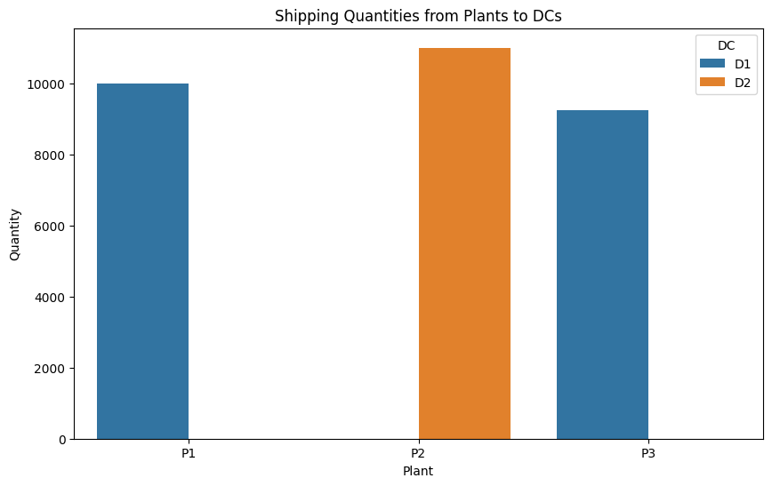

```python
# Plot for Plants to DCs
plt.figure(figsize=(10, 6))
sns.barplot(data=df_plant_dc, x='Plant', y='Quantity', hue='DC')
plt.title('Shipping Quantities from Plants to DCs')
plt.ylabel('Quantity')
plt.xlabel('Plant')
plt.legend(title='DC')
plt.show()
```

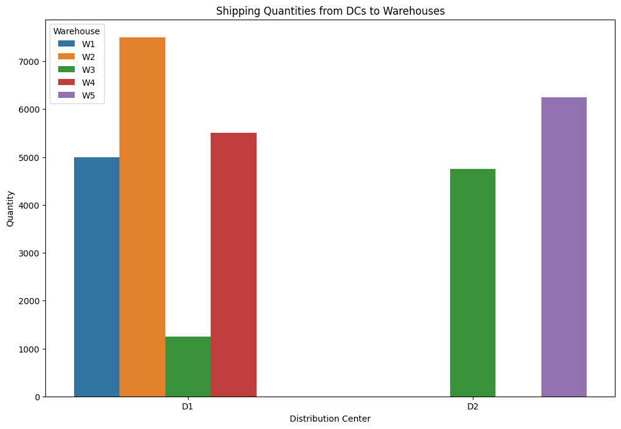

```python
# Plot for DCs to WHs
plt.figure(figsize=(12, 8))
sns.barplot(data=df_dc_wh, x='DC', y='Quantity', hue='WH')
plt.title('Shipping Quantities from DCs to Warehouses')
plt.ylabel('Quantity')
plt.xlabel('Distribution Center')
plt.legend(title='Warehouse')
plt.show()
```

```python
#Create a sequence of shipping costs (P3 to D1) from 0.55 to 0.75 in one cent increments (21 unique values).
new_ship = [i/100 for i in list(range(55,76))]
```

```python
 obj_list = []
 quantities_p3_to_d1 = []
 quantities_p3_to_d2 = []
 quantities_d1_w1 = []
 quantities_d1_w2 = []
 quantities_d1_w3 = []
 quantities_d1_w4 = []
 quantities_d1_w5 = []
 quantities_d2_w1 = []
 quantities_d2_w2 = []
 quantities_d2_w3 = []
 quantities_d2_w4 = []
 quantities_d2_w5 = []
for val in new_ship:
    cost.loc['P3','D1'] = val
    model = runmodel()
    obj_list.append(model.obj.expr())
    quantities_p3_to_d1.append(pe.value(model.P3['D1']))
    quantities_p3_to_d2.append(pe.value(model.P3['D2']))
    quantities_d1_w1.append(pe.value(model.D1['W1']))
    quantities_d1_w2.append(pe.value(model.D1['W2']))
    quantities_d1_w3.append(pe.value(model.D1['W3']))
    quantities_d1_w4.append(pe.value(model.D1['W4']))
    quantities_d1_w5.append(pe.value(model.D1['W5']))
    quantities_d2_w1.append(pe.value(model.D2['W1']))
    quantities_d2_w2.append(pe.value(model.D2['W2']))
    quantities_d2_w3.append(pe.value(model.D2['W3']))
    quantities_d2_w4.append(pe.value(model.D2['W4']))
    quantities_d2_w5.append(pe.value(model.D2['W5']))
```

#### Problem 6b

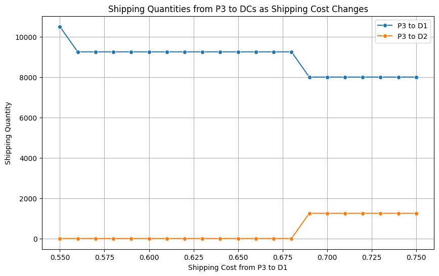

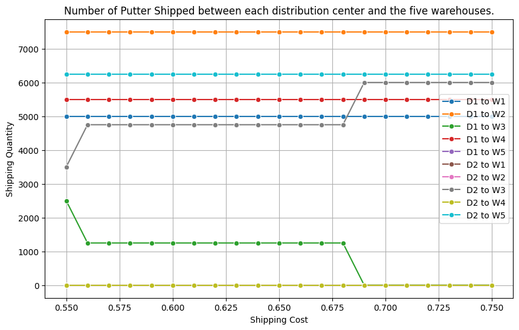

```python
#b. Make two plots showing:
#(1) the number of putters shipped between Plant P3
# and the two distribution centers and
results_df = pd.DataFrame({
    'Shipping_Cost': new_ship,
    'Quantity_P3_D1': quantities_p3_to_d1,
    'Quantity_P3_D2': quantities_p3_to_d2,
})

plt.figure(figsize=(10, 6))
sns.lineplot(x='Shipping_Cost', y='Quantity_P3_D1', data=results_df, marker='o', label='P3 to D1')
sns.lineplot(x='Shipping_Cost', y='Quantity_P3_D2', data=results_df, marker='o', label='P3 to D2')
plt.title('Shipping Quantities from P3 to DCs as Shipping Cost Changes')
plt.xlabel('Shipping Cost from P3 to D1')
plt.ylabel('Shipping Quantity')
plt.grid(True)
plt.legend()
plt.show()
# (2) the number of putters shipped between each distribution center and the five warehouses.
#The lines be shown using different colors.
results_dc_wh = pd.DataFrame({
      'Shipping_Cost': new_ship,
      'Quantity_D1_W1': quantities_d1_w1,
      'Quantity_D1_W2': quantities_d1_w2,
      'Quantity_D1_W3': quantities_d1_w3,
      'Quantity_D1_W4': quantities_d1_w4,
      'Quantity_D1_W5': quantities_d1_w5,
      'Quantity_D2_W1': quantities_d2_w1,
      'Quantity_D2_W2': quantities_d2_w2,
      'Quantity_D2_W3': quantities_d2_w3,
      'Quantity_D2_W4': quantities_d2_w4,
      'Quantity_D2_W5': quantities_d2_w5,

})

plt.figure(figsize=(10, 6))
sns.lineplot(x='Shipping_Cost', y='Quantity_D1_W1', data=results_dc_wh, marker='o', label='D1 to W1')
sns.lineplot(x='Shipping_Cost', y='Quantity_D1_W2', data=results_dc_wh, marker='o', label='D1 to W2')
sns.lineplot(x='Shipping_Cost', y='Quantity_D1_W3', data=results_dc_wh, marker='o', label='D1 to W3')
sns.lineplot(x='Shipping_Cost', y='Quantity_D1_W4', data=results_dc_wh, marker='o', label='D1 to W4')
sns.lineplot(x='Shipping_Cost', y='Quantity_D1_W5', data=results_dc_wh, marker='o', label='D1 to W5')
sns.lineplot(x='Shipping_Cost', y='Quantity_D2_W1', data=results_dc_wh, marker='o', label='D2 to W1')
sns.lineplot(x='Shipping_Cost', y='Quantity_D2_W2', data=results_dc_wh, marker='o', label='D2 to W2')
sns.lineplot(x='Shipping_Cost', y='Quantity_D2_W3', data=results_dc_wh, marker='o', label='D2 to W3')
sns.lineplot(x='Shipping_Cost', y='Quantity_D2_W4', data=results_dc_wh, marker='o', label='D2 to W4')
sns.lineplot(x='Shipping_Cost', y='Quantity_D2_W5', data=results_dc_wh, marker='o', label='D2 to W5')
plt.title('Number of Putter Shipped between each distribution center and the five warehouses.')
plt.xlabel('Shipping Cost')
plt.ylabel('Shipping Quantity')
plt.grid(True)
plt.legend()
plt.show()
```

#### Problem 7

[figure not shown]

```python
demand_seq = list(range(5700,7300,100))
obj_list = []
for val in demand_seq:
  demand.loc['W3'] = val
  model = run_model()
  obj_list.append(model.obj.expr())
zip_list7 = list(zip(demand_seq,obj_list))
df7 = pd.DataFrame(zip_list7, columns = ['W3 Demand','Total Cost'])
plt.figure(figsize = (8,5))
sns.lineplot(x = 'W3 Demand', y = 'Total Cost', data = df7, marker = 'o')
plt.xlabel('W3 Demand')
plt.ylabel('Total Cost')
plt.show()
```

The prompt says 5700 - 8200 units for the demand in W3 but after a demand of 7200 the solver can not find a feasable soultion of the model with the constraints that are presently on it.